# support_vector_machine

### 5

We have seen that we can fit an SVM with a non-linear kernel in order to perform classification using a non-linear decision boundary. We will now see that we can also obtain a non-linear decision boundary by performing logistic regression using non-linear transformations of the features.

1. Generate a data set with n = 500 and p = 2, such that the observations belong to two classes with a quadratic decision boundary between them. For instance, you can do this as follows:

```r
x1=runif(500)-0.5
x2=runif(500)-0.5
y=1*(x1^2-x2^2 > 0)
```

2. Plot the observations, colored according to their class labels. Your plot should display X1 on the x-axis, and X2 on the y- axis.

```r
library(tidyverse)
```

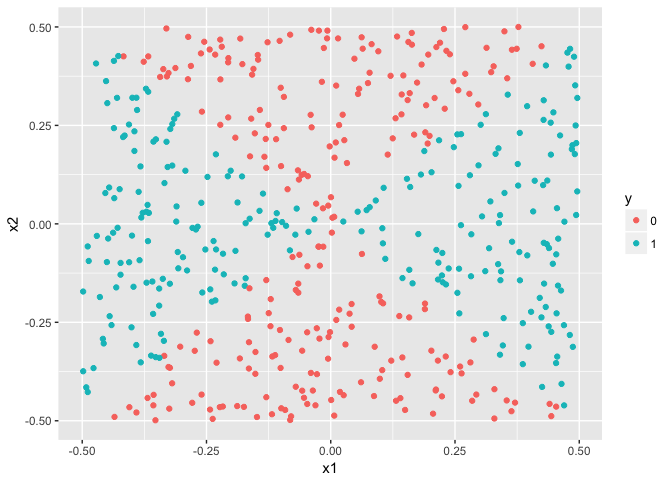

```r
dat <- data.frame(x1 = x1,
                  x2 = x2,
                  y = as.factor(y))

dat %>%
  ggplot() +
  geom_point(aes(x = x1, y = x2, color = y))
```

3. Fit a logistic regression model to the data, using X1 and X2 as predictors.

```r
library(ISLR)
glm.fits=glm(y ~ ., data=dat,family=binomial)
summary(glm.fits)
```

```
##
## Call:
## glm(formula = y ~ ., family = binomial, data = dat)
##
## Deviance Residuals:
##    Min      1Q  Median      3Q     Max
## -1.196  -1.160  -1.133   1.194   1.229
##
## Coefficients:
##             Estimate Std. Error z value Pr(>|z|)
## (Intercept) -0.03983    0.08949  -0.445    0.656
## x1           0.11727    0.31321   0.374    0.708
## x2          -0.06411    0.30463  -0.210    0.833
##
## (Dispersion parameter for binomial family taken to be 1)
##
##     Null deviance: 692.95  on 499  degrees of freedom
## Residual deviance: 692.77  on 497  degrees of freedom
## AIC: 698.77
##
## Number of Fisher Scoring iterations: 3
```

4. Apply this model to the training data in order to obtain a predicted class label for each training observation. Plot the observations, colored according to the predicted class labels. The decision boundary should be linear.

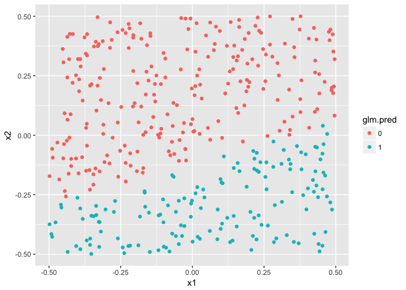

```r
set.seed(1)
train = sample(500, 500*0.8)
glm.fits=glm(y ~ ., data=dat[train,],family=binomial)
glm.probs=predict(glm.fits,type="response")
glm.pred <- ifelse(glm.probs > .5, 1, 0) %>% as.character() %>% as.factor()

dat[train,] %>%
  ggplot() +
  geom_point(aes(x = x1, y = x2, color = glm.pred))
```

5. Now fit a logistic regression model to the data using non-linear functions of X1 and X2 as predictors (e.g. X12, X1 ×X2, log(X2), and so forth).

```r
library(ISLR)
glm.fits=glm(y ~ poly(x1, 2) + x1*x2, data=dat,family=binomial)
summary(glm.fits)
```

```
##
## Call:
## glm(formula = y ~ poly(x1, 2) + x1 * x2, family = binomial, data = dat)
##
## Deviance Residuals:
##     Min       1Q   Median       3Q      Max
## -2.4169  -0.7427  -0.5938   0.7615   1.8990
##
## Coefficients: (1 not defined because of singularities)
##              Estimate Std. Error z value Pr(>|z|)
## (Intercept)   0.07463    0.11284   0.661    0.508
## poly(x1, 2)1  1.61592    2.69516   0.600    0.549
## poly(x1, 2)2 34.33414    3.12900  10.973   <2e-16 ***
## x1                 NA         NA      NA       NA
## x2           -0.04964    0.37041  -0.134    0.893
## x1:x2        -1.26469    1.43849  -0.879    0.379
## ---
## Signif. codes:  0 '***' 0.001 '**' 0.01 '*' 0.05 '.' 0.1 ' ' 1
##
## (Dispersion parameter for binomial family taken to be 1)
##
##     Null deviance: 692.95  on 499  degrees of freedom
## Residual deviance: 505.68  on 495  degrees of freedom
## AIC: 515.68
##
## Number of Fisher Scoring iterations: 4
```

6. Apply this model to the training data in order to obtain a predicted class label for each training observation. Plot the observations, colored according to the predicted class labels. The decision boundary should be obviously non-linear. If it is not, then repeat (a)-(e) until you come up with an example in which the predicted class labels are obviously non-linear.

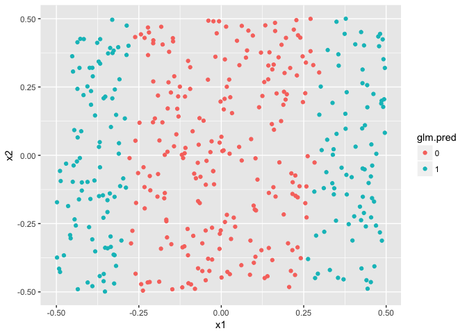

```r
glm.fits=glm(y ~ poly(x1, 2) + x1*x2, data=dat[train,],family=binomial)
glm.probs=predict(glm.fits,type="response")
glm.pred <- ifelse(glm.probs > .5, 1, 0) %>% as.character() %>% as.factor()

dat[train,] %>%
  ggplot() +
  geom_point(aes(x = x1, y = x2, color = glm.pred))
```

7. Fit a support vector classifier to the data with X1 and X2 as predictors. Obtain a class prediction for each training observation. Plot the observations, colored according to the predicted class labels.

```r
set.seed(1)
tune.out=tune(svm,y~.,data=dat[train,],kernel="linear",ranges=list(cost=c(0.001, 0.01, 0.1, 1,5,10,100)))
summary(tune.out)
```

```
##
## Parameter tuning of 'svm':
##
## - sampling method: 10-fold cross validation
##
## - best parameters:
##  cost
##     5
##
## - best performance: 0.5225
##
## - Detailed performance results:
##    cost  error dispersion
## 1 1e-03 0.5325 0.07732507
## 2 1e-02 0.5325 0.07732507
## 3 1e-01 0.5275 0.08287373
## 4 1e+00 0.5250 0.08498366
## 5 5e+00 0.5225 0.08535058
## 6 1e+01 0.5225 0.08535058
## 7 1e+02 0.5225 0.08535058
```

```r
bestmod=tune.out$best.model
summary(bestmod)
```

```
##
## Call:
## best.tune(method = svm, train.x = y ~ ., data = dat[train, ],
##     ranges = list(cost = c(0.001, 0.01, 0.1, 1, 5, 10, 100)),
##     kernel = "linear")
##
##
## Parameters:
##    SVM-Type:  C-classification
##  SVM-Kernel:  linear
##        cost:  5
##       gamma:  0.5
##
## Number of Support Vectors:  393
##
##  ( 197 196 )
##
##
## Number of Classes:  2
##
## Levels:
##  0 1
```

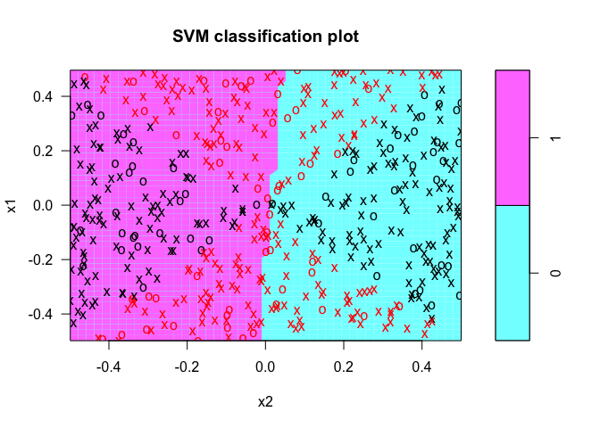

```r
plot(bestmod, dat)
```

```r
ypred=predict(bestmod ,dat[-train,])
table(predict=ypred, truth=dat[-train,]$y)
```

```
##        truth
## predict  0  1
##       0 21 25
##       1 31 23
```

```r
(25+31)/100 # 0.56 test error
```

```
## [1] 0.56
```

8. Fit a SVM using a non-linear kernel to the data. Obtain a class prediction for each training observation. Plot the observations, colored according to the predicted class labels.

```r
set.seed(1)
tune.out=tune(svm, y~., data=dat[train,], kernel="radial",ranges=list(cost=c(0.1,1,10,100,1000),gamma=c(0.5,1,2,3,4) ))
summary(tune.out)
```

```
##
## Parameter tuning of 'svm':
##
## - sampling method: 10-fold cross validation
##
## - best parameters:
##  cost gamma
##  1000   0.5
##
## - best performance: 0.0275
##
## - Detailed performance results:
##     cost gamma  error dispersion
## 1  1e-01   0.5 0.0550 0.05627314
## 2  1e+00   0.5 0.0650 0.04116363
## 3  1e+01   0.5 0.0450 0.05109903
## 4  1e+02   0.5 0.0400 0.02108185
## 5  1e+03   0.5 0.0275 0.02188988
## 6  1e-01   1.0 0.0550 0.04048319
## 7  1e+00   1.0 0.0600 0.04281744
## 8  1e+01   1.0 0.0450 0.03496029
## 9  1e+02   1.0 0.0325 0.01687371
## 10 1e+03   1.0 0.0350 0.02415229
## 11 1e-01   2.0 0.0575 0.04257347
## 12 1e+00   2.0 0.0425 0.02898755
## 13 1e+01   2.0 0.0475 0.02486072
## 14 1e+02   2.0 0.0325 0.02371708
## 15 1e+03   2.0 0.0350 0.02415229
## 16 1e-01   3.0 0.0550 0.04048319
## 17 1e+00   3.0 0.0550 0.04048319
## 18 1e+01   3.0 0.0450 0.02297341
## 19 1e+02   3.0 0.0375 0.02946278
## 20 1e+03   3.0 0.0475 0.02751262
## 21 1e-01   4.0 0.0575 0.03917553
## 22 1e+00   4.0 0.0525 0.04632314
## 23 1e+01   4.0 0.0450 0.02838231
## 24 1e+02   4.0 0.0450 0.03291403
## 25 1e+03   4.0 0.0425 0.02898755
```

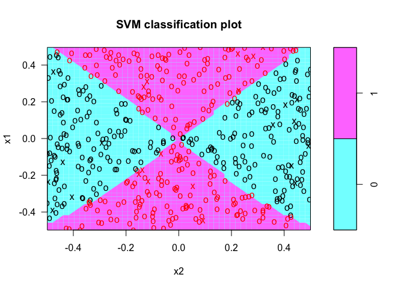

```r
plot(tune.out$best.model,dat)
```

```r
table(true=dat[-train,"y"], pred=predict(tune.out$best.model, newdata=dat[-train,]))
```

```
##     pred
## true  0  1
##    0 51  1
##    1  0 48
```

```r
(0+1)/100 # 0.01 test error
```

```
## [1] 0.01
```

1. Comment on your results. SVM has the best performance